# Part II - Prosper Loan Data Exploration

# by Jean Felix Ndayambaje

## Loan status

### Observation

1. Most of the loans in the data set are actually current loans.
2. Past due loans are split in several groups based on the length of payment delay.
3. Other big part is completed loans, defaulted loans compromise a minority, however chargedoff loans also comporomise a substanial amount.

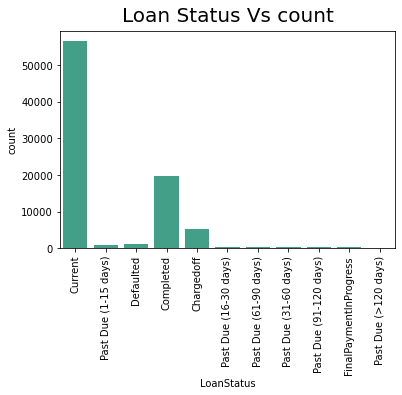

## Employment Status

### Observation

1. The majority of borrowers are employed and all other categories as small part of borrowers.
2. In small Group full time has highest, after that self empolyed are there and so on.

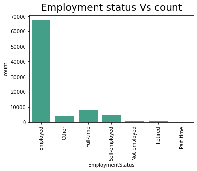

## Stated Monthly Income

### Observation

With a boundary of mean and 3 times standard deviations distribution of monthly income still has noticeable right skew but now we can see that mode is about 5000.

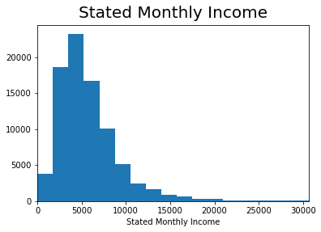

## Status and Prosper Rating:

#### Observation

1. The most frequent rating among defaulted loans is actually D.
2. And the most frequent rating among Completed is alsoDand second highest is A and so on.

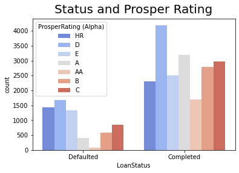

## Credit Start with Listing Category

#### Observation

In both of the Graphs the debt Consolidation have most frequency among all of them

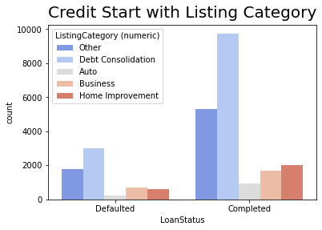

## Loan Status and Loan Amount

#### Observation

As from Above Graph we can state that defaulted credits tend to be smaller than completed credits onces.

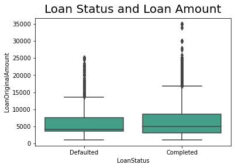

## Prosper Rating and Employment Status

#### Observation

Lower ratings seem to have greater proportions of individuals with employment status Not Employed, Self-employed, Retired and Part-Time

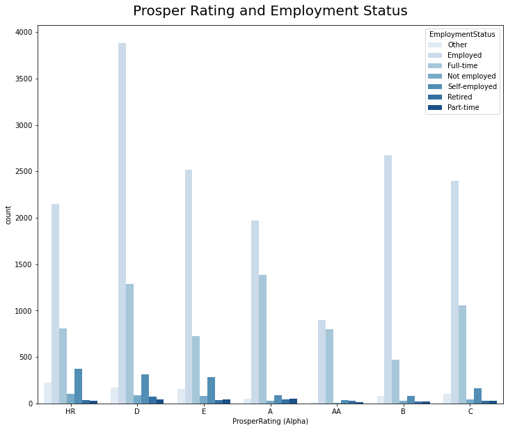

## Rating, Loan Amount and Loan Status

#### Observation

1. Except for the lowest ratings defaulted credits tend to be larger than completed.
2. Most of the defaulted credits comes from individuals with low Prosper rating

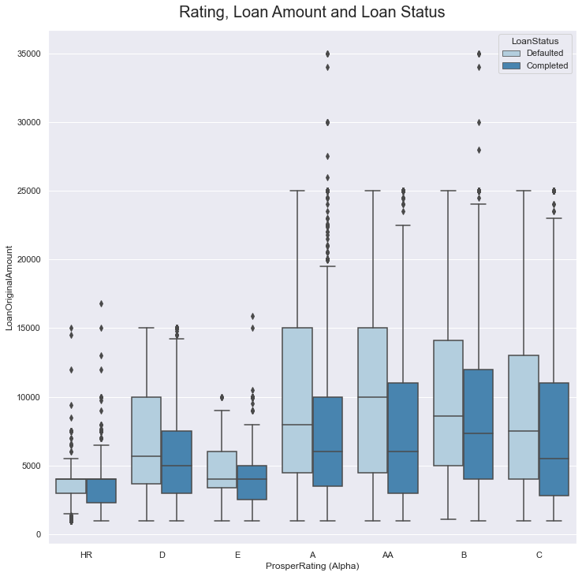

## Relationships between Credit category, Credit rating and outcome of Credit.

#### Observation

1. There are 5 graphs in the second one has much up and downs in it other than all of them.
2. There is no substantial difference for default rates in different categories broken up by ratings.

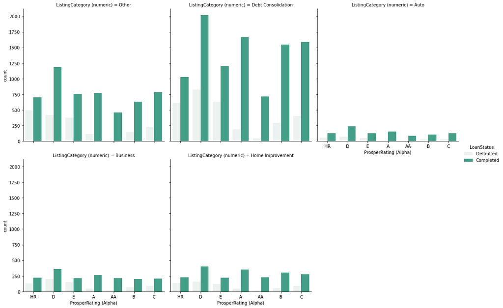